# final_project

**Capstone Project:Final Submission Notebook**

**Pneumonia Detection Challenge**

We have used the RSNA Pneumonia Detection Challenge dataset for this project [link to the competition](https://www.kaggle.com/c/rsna-pneumonia-detection-challenge)

What is Pneumonia?

Pneumonia is an infection in one or both lungs. Bacteria, viruses, and fungi cause it. The infection causes inflammation in the air sacs in your lungs, which are called alveoli. Pneumonia accounts for over 15% of all deaths of children under 5 years old internationally. In 2017, 920,000 children under the age of 5 died from the disease. It requires review of a chest radiograph (CXR) by highly trained specialists and confirmation through clinical history, vital signs and laboratory exams. Pneumonia usually manifests as an area or areas of increased opacity on CXR. However, the diagnosis of pneumonia on CXR is complicated because of a number of other conditions in the lungs such as fluid overload (pulmonary edema), bleeding, volume loss (atelectasis or collapse), lung cancer, or postradiation or surgical changes. Outside of the lungs, fluid in the pleural space (pleural effusion) also appears as increased opacity on CXR. When available, comparison of CXRs of the patient taken at different time points and correlation with clinical symptoms and history are helpful in making the diagnosis.

CXRs are the most commonly performed diagnostic imaging study. A number of factors such as positioning of the patient and depth of inspiration can alter the appearance of the CXR, complicating interpretation further. In addition, clinicians are faced with reading high volumes of images every shift.

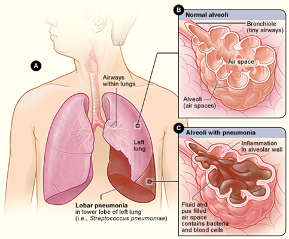

**Brief on the Data**

**Files Needed:**

This is a two-stage challenge. We will need the images for the current stage - provided as train_images folder and test_images folder. We will also need the training data - stage_2_train_labels.csv - and the sample submission stage_2_sample_submission.csv, which provides the IDs for the test set, as well as a sample of what the submission should look like. The file stage_2_detailed_class_info.csv contains detailed information about the positive and negative classes in the training set, and may be used to build more nuanced models.

**Data Format**

- The training data is provided as a set of patientIds and bounding boxes. Bounding boxes are defined as follows: x-min y-min width height.
- There is also a binary target column, Target, indicating pneumonia or non-pneumonia.There may be multiple rows per patientId.

**Files Decscription**

- stage_2_train.csv - the training set. Contains patientIds and bounding box / target information.
- stage_2_sample_submission.csv - a sample submission file in the correct format. Contains patientIds for the test set. Note that the sample submission contains one box per image, but there is no limit to the number of bounding boxes that can be assigned to a given image.
- stage_2_detailed_class_info.csv - provides detailed information about the type of positive or negative class for each image.
- train_images-Contains DICOM images used to train the model.
- test_images-Contains DICOM images used to test the model.

**Data Fields**

- patientId _- A patientId. Each patientId corresponds to a unique image.
- x_ - the upper-left x coordinate of the bounding box.
- y_ - the upper-left y coordinate of the bounding box.
- width_ - the width of the bounding box.
- height_ - the height of the bounding box.
- Target_ - the binary Target, indicating whether this sample has evidence of pneumonia.

```python
#Importing needed packages
!pip install tensorflow
import tensorflow as tf
from tensorflow import keras
```

```python
import numpy as np
import pandas as pd
import matplotlib.pyplot as plt
import seaborn as sns
%matplotlib inline
import os
import csv
import random
!pip install pydicom
import pydicom as dicom
from tqdm import tqdm
from skimage import measure
from skimage.transform import resize
import cv2
import PIL
from glob import glob
from sklearn.model_selection import train_test_split
from sklearn.preprocessing import LabelEncoder
from sklearn.preprocessing import LabelBinarizer
from sklearn.preprocessing import StandardScaler
from tensorflow.keras.layers import Layer, Convolution2D, Flatten, Dense
from tensorflow.keras.layers import Concatenate, UpSampling2D, Conv2D, Reshape, GlobalAveragePooling2D
from tensorflow.keras import losses,optimizers
from tensorflow.keras.layers import Dense,  Activation, Flatten,Dropout,MaxPooling2D,BatchNormalization
from tensorflow.keras.models import Model
from tensorflow.keras.models import Sequential
from tensorflow.keras import backend as K
import tensorflow.keras.utils as pltUtil
from tensorflow.keras.utils import Sequence
import math
import scipy.stats as stats
from matplotlib.patches import Rectangle
from tensorflow.keras import layers, models
from tensorflow.keras.utils import to_categorical
from tensorflow.keras.models import Sequential
from tensorflow.keras.layers import Flatten, Dense ,LeakyReLU,GlobalMaxPooling2D
from tensorflow.keras import regularizers, optimizers
from sklearn.metrics import r2_score
from tensorflow.keras.models import load_model
from tensorflow.keras.optimizers import RMSprop
from tensorflow.keras.preprocessing.image import ImageDataGenerator
from tensorflow.keras.optimizers import Adam
from keras import applications
from tensorflow.keras.applications.vgg16 import VGG16
from tensorflow.keras.applications import ResNet50V2
from tensorflow.keras.applications import DenseNet121
from tensorflow.keras import datasets
from tensorflow.keras.layers import BatchNormalization
from tabulate import tabulate
!pip install texttable
import warnings
warnings.filterwarnings('ignore')
```

```
     |████████████████████████████████| 2.0 MB 5.0 MB/s
```

```python
#Importing the dataset , Exploratory Data Analysis and Visualization
from google.colab import drive
drive.mount('/content/drive')
```

```python
os.chdir('/content/drive/MyDrive/capstone')
```

```python
!ls
```

```
'GCP Credits Request Link - RSNA (1).txt'   stage_2_train_labels.csv
 stage_2_detailed_class_info.csv	    test_images
'stage_2_sample_submission (1).csv'	    train_images
```

```python
#Reading the train label file and loading it into train_lables dataframe
train_labels= pd.read_csv('stage_2_train_labels.csv')
train_labels
```

|  | patientId | x | y | width | height | Target |
| --- | --- | --- | --- | --- | --- | --- |
| 0 | 0004cfab-14fd-4e49-80ba-63a80b6bddd6 | NaN | NaN | NaN | NaN | 0 |
| 1 | 00313ee0-9eaa-42f4-b0ab-c148ed3241cd | NaN | NaN | NaN | NaN | 0 |
| 2 | 00322d4d-1c29-4943-afc9-b6754be640eb | NaN | NaN | NaN | NaN | 0 |
| 3 | 003d8fa0-6bf1-40ed-b54c-ac657f8495c5 | NaN | NaN | NaN | NaN | 0 |
| 4 | 00436515-870c-4b36-a041-de91049b9ab4 | 264.0 | 152.0 | 213.0 | 379.0 | 1 |
| ... | ... | ... | ... | ... | ... | ... |
| 30222 | c1ec14ff-f6d7-4b38-b0cb-fe07041cbdc8 | 185.0 | 298.0 | 228.0 | 379.0 | 1 |
| 30223 | c1edf42b-5958-47ff-a1e7-4f23d99583ba | NaN | NaN | NaN | NaN | 0 |
| 30224 | c1f6b555-2eb1-4231-98f6-50a963976431 | NaN | NaN | NaN | NaN | 0 |
| 30225 | c1f7889a-9ea9-4acb-b64c-b737c929599a | 570.0 | 393.0 | 261.0 | 345.0 | 1 |
| 30226 | c1f7889a-9ea9-4acb-b64c-b737c929599a | 233.0 | 424.0 | 201.0 | 356.0 | 1 |

30227 rows × 6 columns

```python
# Shape of the dataframe
train_labels.shape
```

```
(30227, 6)
```

```python
# Size of the dataframe
train_labels.size
```

```
181362
```

```python
# Basic information of the dataframe
train_labels.info()
```

```
<class 'pandas.core.frame.DataFrame'>
RangeIndex: 30227 entries, 0 to 30226
Data columns (total 6 columns):
 #   Column     Non-Null Count  Dtype
---  ------     --------------  -----
 0   patientId  30227 non-null  object
 1   x          9555 non-null   float64
 2   y          9555 non-null   float64
 3   width      9555 non-null   float64
 4   height     9555 non-null   float64
 5   Target     30227 non-null  int64
dtypes: float64(4), int64(1), object(1)
memory usage: 1.4+ MB
```

```python
train_labels.describe()
```

|  | x | y | width | height | Target |
| --- | --- | --- | --- | --- | --- |
| count | 9555.000000 | 9555.000000 | 9555.000000 | 9555.000000 | 30227.000000 |
| mean | 394.047724 | 366.839560 | 218.471376 | 329.269702 | 0.316108 |
| std | 204.574172 | 148.940488 | 59.289475 | 157.750755 | 0.464963 |
| min | 2.000000 | 2.000000 | 40.000000 | 45.000000 | 0.000000 |
| 25% | 207.000000 | 249.000000 | 177.000000 | 203.000000 | 0.000000 |
| 50% | 324.000000 | 365.000000 | 217.000000 | 298.000000 | 0.000000 |
| 75% | 594.000000 | 478.500000 | 259.000000 | 438.000000 | 1.000000 |
| max | 835.000000 | 881.000000 | 528.000000 | 942.000000 | 1.000000 |

```python
train_labels['patientId'].nunique()
```

```
26684
```

```python
#There are 26684 Unique patientIds in the dataframe, the above shows that each patientId has multiple rows in the dataframe
```

```python
# finding how many patients out of 26684 has Pneumonia or not in our dataset
# Creating Varibales with and without Pneumonia to final the percentage distribution of data

one = train_labels[train_labels.Target == 1].drop_duplicates('patientId').shape[0]
zero = train_labels[train_labels.Target == 0].drop_duplicates('patientId').shape[0]
total = train_labels.drop_duplicates('patientId').shape[0]
```

```python
zero/total
```

```
0.774696447309249
```

```
No of Patients with Pneumonia: 6012 - 23.0% of the entire dataset
No of Patients without Pneumonia: 20672 - 77.0% of the entire dataset
```

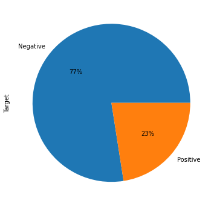

```python
print(f'No of Patients with Pneumonia: {one} - {round(one/total*100, 0)}% of the entire dataset')
print(f'No of Patients without Pneumonia: {zero} - {round(zero/total*100, 0)}% of the entire dataset')
_ = train_labels.drop_duplicates('patientId').drop_duplicates('patientId')['Target'].value_counts().plot(kind = 'pie', autopct = '%.0f%%', labels = ['Negative', 'Positive'], figsize = (10, 6))
```

```python
# Checking nulls in bounding box columns:
print('Number of nulls in bounding box columns: {}'.format(train_labels[['x', 'y', 'width', 'height']].isnull().sum().to_dict()))
```

```
Number of nulls in bounding box columns: {'x': 20672, 'y': 20672, 'width': 20672, 'height': 20672}
```

```python
#Thus, we can see that number of nulls in bounding box columns are equal to the number of 0's we have in the Target column.
```

```python
#Importing the detailed class info file and EDA
class_labels = pd.read_csv('stage_2_detailed_class_info.csv')
class_labels
```

|  | patientId | class |
| --- | --- | --- |
| 0 | 0004cfab-14fd-4e49-80ba-63a80b6bddd6 | No Lung Opacity / Not Normal |
| 1 | 00313ee0-9eaa-42f4-b0ab-c148ed3241cd | No Lung Opacity / Not Normal |
| 2 | 00322d4d-1c29-4943-afc9-b6754be640eb | No Lung Opacity / Not Normal |
| 3 | 003d8fa0-6bf1-40ed-b54c-ac657f8495c5 | Normal |
| 4 | 00436515-870c-4b36-a041-de91049b9ab4 | Lung Opacity |
| ... | ... | ... |
| 30222 | c1ec14ff-f6d7-4b38-b0cb-fe07041cbdc8 | Lung Opacity |
| 30223 | c1edf42b-5958-47ff-a1e7-4f23d99583ba | Normal |
| 30224 | c1f6b555-2eb1-4231-98f6-50a963976431 | Normal |
| 30225 | c1f7889a-9ea9-4acb-b64c-b737c929599a | Lung Opacity |
| 30226 | c1f7889a-9ea9-4acb-b64c-b737c929599a | Lung Opacity |

30227 rows × 2 columns

```python
#Some information about the data field present in the 'stage_2_detailed_class_info.csv':

#patientId - A patientId. Each patientId corresponds to a unique image
#class - Have three values depending what is the current state of the patient's lung: 'No Lung Opacity / Not Normal', 'Normal' and 'Lung Opacity'.
```

```python
# Shape of the dataframe
class_labels.shape
```

```
(30227, 2)
```

```python
# Size of the dataframe
class_labels.size
```

```
60454
```

```python
# Basic information about the file
class_labels.info()
```

```
<class 'pandas.core.frame.DataFrame'>
RangeIndex: 30227 entries, 0 to 30226
Data columns (total 2 columns):
 #   Column     Non-Null Count  Dtype
---  ------     --------------  -----
 0   patientId  30227 non-null  object
 1   class      30227 non-null  object
dtypes: object(2)
memory usage: 472.4+ KB
```

```python
class_labels.describe()
```

|  | patientId | class |
| --- | --- | --- |
| count | 30227 | 30227 |
| unique | 26684 | 3 |
| top | 3239951b-6211-4290-b237-3d9ad17176db | No Lung Opacity / Not Normal |
| freq | 4 | 11821 |

```python
class_labels['patientId'].nunique()
```

```
26684
```

```python
# Printing the unique values in Class column to do the further analysis
print(sorted(class_labels['class'].unique()))
```

```
['Lung Opacity', 'No Lung Opacity / Not Normal', 'Normal']
```

```python
#There are 26684 Unique patientIds in the dataframe, the above shows that each patientId has multiple rows in the dataframe
```

```python
# The data is distributed across in the class column as below
(class_labels['class'].value_counts() / class_labels['patientId'].count()) * 100
```

```
No Lung Opacity / Not Normal    39.107421
Lung Opacity                    31.610812
Normal                          29.281768
Name: class, dtype: float64
```

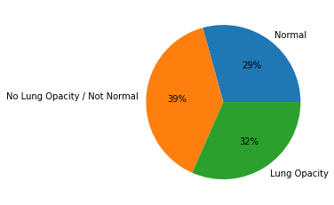

```python
figsize = (10, 6)
_ = class_labels['class'].value_counts().sort_index(ascending = False).plot(kind = 'pie', autopct = '%.0f%%').set_ylabel('')
```

```python
# Checking nulls in class_labels:
print('Number of nulls in class columns: {}'.format(class_labels['class'].isnull().sum()))
```

```
Number of nulls in class columns: 0
```

```python
# Checking whether each patientId has only one type of class or not
class_labels.groupby(['patientId'])['class'].nunique().max()
```

```
1
```

```python
#Merging both the dataframes
#Both train_lables and class_labels can be merged because of same number of rows and same number of unique patient IDs available in both the dataframes
# Merging the two dataset - 'train_labels' and 'class_labels':
training_data = pd.concat([train_labels, class_labels['class']], axis = 1)
print('After merging, the dataset looks like: \n')
training_data
```

```
After merging, the dataset looks like:
```

|  | patientId | x | y | width | height | Target | class |
| --- | --- | --- | --- | --- | --- | --- | --- |
| 0 | 0004cfab-14fd-4e49-80ba-63a80b6bddd6 | NaN | NaN | NaN | NaN | 0 | No Lung Opacity / Not Normal |
| 1 | 00313ee0-9eaa-42f4-b0ab-c148ed3241cd | NaN | NaN | NaN | NaN | 0 | No Lung Opacity / Not Normal |
| 2 | 00322d4d-1c29-4943-afc9-b6754be640eb | NaN | NaN | NaN | NaN | 0 | No Lung Opacity / Not Normal |
| 3 | 003d8fa0-6bf1-40ed-b54c-ac657f8495c5 | NaN | NaN | NaN | NaN | 0 | Normal |
| 4 | 00436515-870c-4b36-a041-de91049b9ab4 | 264.0 | 152.0 | 213.0 | 379.0 | 1 | Lung Opacity |
| ... | ... | ... | ... | ... | ... | ... | ... |
| 30222 | c1ec14ff-f6d7-4b38-b0cb-fe07041cbdc8 | 185.0 | 298.0 | 228.0 | 379.0 | 1 | Lung Opacity |
| 30223 | c1edf42b-5958-47ff-a1e7-4f23d99583ba | NaN | NaN | NaN | NaN | 0 | Normal |
| 30224 | c1f6b555-2eb1-4231-98f6-50a963976431 | NaN | NaN | NaN | NaN | 0 | Normal |
| 30225 | c1f7889a-9ea9-4acb-b64c-b737c929599a | 570.0 | 393.0 | 261.0 | 345.0 | 1 | Lung Opacity |
| 30226 | c1f7889a-9ea9-4acb-b64c-b737c929599a | 233.0 | 424.0 | 201.0 | 356.0 | 1 | Lung Opacity |

30227 rows × 7 columns

```python
# Shape of the dataframe
training_data.shape
```

```
(30227, 7)
```

```python
# Size of the dataframe
training_data.size
```

```
211589
```

```python
#Basic information on the dataset
training_data.info()
```

```
<class 'pandas.core.frame.DataFrame'>
RangeIndex: 30227 entries, 0 to 30226
Data columns (total 7 columns):
 #   Column     Non-Null Count  Dtype
---  ------     --------------  -----
 0   patientId  30227 non-null  object
 1   x          9555 non-null   float64
 2   y          9555 non-null   float64
 3   width      9555 non-null   float64
 4   height     9555 non-null   float64
 5   Target     30227 non-null  int64
 6   class      30227 non-null  object
dtypes: float64(4), int64(1), object(2)
memory usage: 1.6+ MB
```

```python
training_data.describe()
```

|  | x | y | width | height | Target |
| --- | --- | --- | --- | --- | --- |
| count | 9555.000000 | 9555.000000 | 9555.000000 | 9555.000000 | 30227.000000 |
| mean | 394.047724 | 366.839560 | 218.471376 | 329.269702 | 0.316108 |
| std | 204.574172 | 148.940488 | 59.289475 | 157.750755 | 0.464963 |
| min | 2.000000 | 2.000000 | 40.000000 | 45.000000 | 0.000000 |
| 25% | 207.000000 | 249.000000 | 177.000000 | 203.000000 | 0.000000 |
| 50% | 324.000000 | 365.000000 | 217.000000 | 298.000000 | 0.000000 |
| 75% | 594.000000 | 478.500000 | 259.000000 | 438.000000 | 1.000000 |
| max | 835.000000 | 881.000000 | 528.000000 | 942.000000 | 1.000000 |

```python
training_data.isna().sum() #checking for null values
```

```
patientId        0
x            20672
y            20672
width        20672
height       20672
Target           0
class            0
dtype: int64
```

```python
training_data['Target'].value_counts() #Value count of the target
```

```
0    20672
1     9555
Name: Target, dtype: int64
```

```python
training_data['class'].value_counts() #Frequency of the class
```

```
No Lung Opacity / Not Normal    11821
Lung Opacity                     9555
Normal                           8851
Name: class, dtype: int64
```

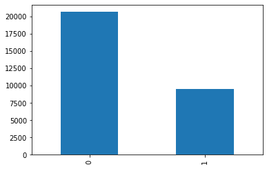

```python
pd.value_counts(training_data['Target']).plot(kind="bar") #Bar plot
```

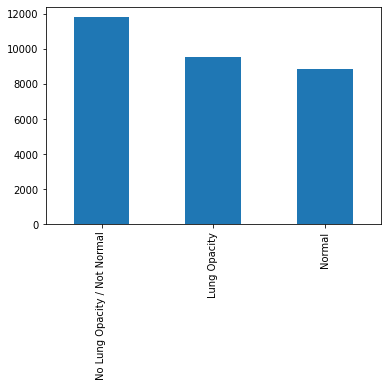

```python
pd.value_counts(training_data['class']).plot(kind="bar") #Bar plot
```

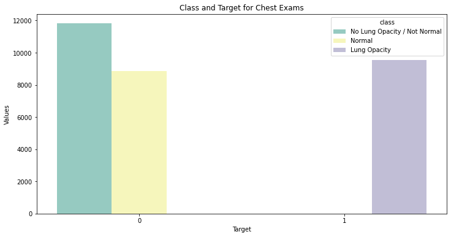

```python
#How the target in train_labels and class in class_labels are associated

fig, ax = plt.subplots(nrows = 1, figsize = (12, 6))
temp = training_data.groupby('Target')['class'].value_counts()
data_target_class = pd.DataFrame(data = {'Values': temp.values}, index = temp.index).reset_index()
sns.barplot(ax = ax, x = 'Target', y = 'Values', hue = 'class', data = data_target_class, palette = 'Set3')
plt.title('Class and Target for Chest Exams')
```

```python
#So, from the above we can conclude the below Grouping:
#If the Target is 0, the class would be either - No Lung Opacity / Not Normal or Normal
#If the Targe is 1, the class would be Lung Opacity
```

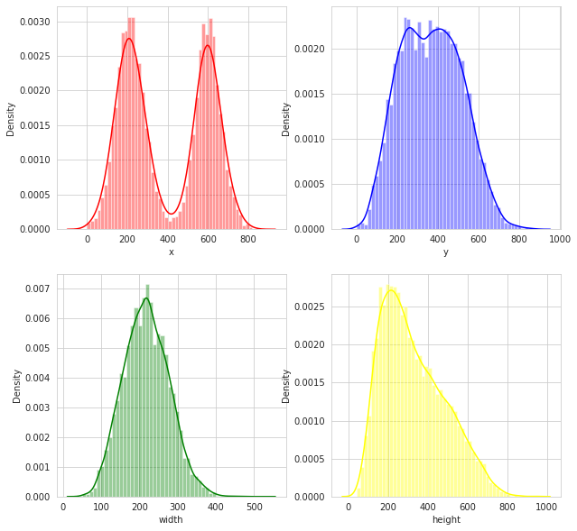

```python
#Distribution Plot
target1 = training_data[training_data['Target']==1]
sns.set_style('whitegrid')
plt.figure()
fig, ax = plt.subplots(2,2,figsize=(10,10))
sns.distplot(target1['x'],kde=True,bins=50, color="red", ax=ax[0,0])
sns.distplot(target1['y'],kde=True,bins=50, color="blue", ax=ax[0,1])
sns.distplot(target1['width'],kde=True,bins=50, color="green", ax=ax[1,0])
sns.distplot(target1['height'],kde=True,bins=50, color="yellow", ax=ax[1,1])
locs, labels = plt.xticks()
plt.tick_params(axis='both', which='major', labelsize=10)
plt.show()
```

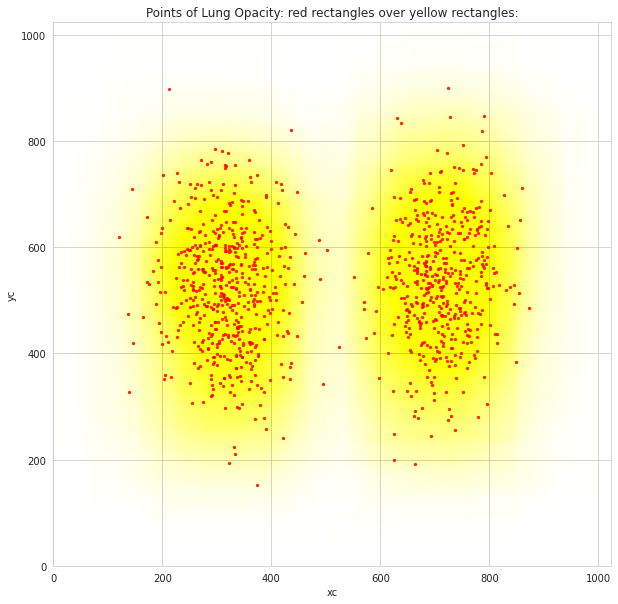

```python
#Heatmap
fig, ax = plt.subplots(1,1,figsize=(10,10))
target2 = target1.sample(1000)
target2['xc'] = target2['x'] + target2['width'] / 2
target2['yc'] = target2['y'] + target2['height'] / 2
plt.title("Points of Lung Opacity: red rectangles over yellow rectangles:")
target2.plot.scatter(x='xc', y='yc', xlim=(0,1024), ylim=(0,1024), ax=ax, alpha=0.8, marker=".", color="red")
for i, crt_sample in target2.iterrows():
    ax.add_patch(Rectangle(xy=(crt_sample['x'], crt_sample['y']),width=crt_sample['width'],height=crt_sample['height'],alpha=3.5e-3, color="yellow"))
plt.show()
```

```python
#loading the train and test images
training_image_path = "train_images"
print("Number of images in train set:", len(os.listdir(training_image_path)))
```

```
Number of images in train set: 26718
```

```python
testing_image_path="test_images"
print("Number of images in test set:", len(os.listdir(testing_image_path)))
```

```
Number of images in test set: 3000
```

```python
# Creating images dataframe with 2 columns - path of the dicom file and associated patientId
# Every DCM filename is the patientId
images = pd.DataFrame({'path': glob(os.path.join(training_image_path, '*.dcm'))})
images['patientId'] = images['path'].map(lambda x:os.path.splitext(os.path.basename(x))[0])
print('Columns in the training images dataframe: {}'.format(list(images.columns)))
```

```
Columns in the training images dataframe: ['path', 'patientId']
```

```python
# Merging the images dataframe with training_data dataframe
training_data = training_data.merge(images, on = 'patientId', how = 'left')
print('After merging the two dataframe, the training_data has {} rows and {} columns.'.format(training_data.shape[0], training_data.shape[1]))
```

```
After merging the two dataframe, the training_data has 30227 rows and 8 columns.
```

```python
training_data
```

|  | patientId | x | y | width | height | Target | class | path |
| --- | --- | --- | --- | --- | --- | --- | --- | --- |
| 0 | 0004cfab-14fd-4e49-80ba-63a80b6bddd6 | NaN | NaN | NaN | NaN | 0 | No Lung Opacity / Not Normal | train_images/0004cfab-14fd-4e49-80ba-63a80b6bd... |
| 1 | 00313ee0-9eaa-42f4-b0ab-c148ed3241cd | NaN | NaN | NaN | NaN | 0 | No Lung Opacity / Not Normal | train_images/00313ee0-9eaa-42f4-b0ab-c148ed324... |
| 2 | 00322d4d-1c29-4943-afc9-b6754be640eb | NaN | NaN | NaN | NaN | 0 | No Lung Opacity / Not Normal | train_images/00322d4d-1c29-4943-afc9-b6754be64... |
| 3 | 003d8fa0-6bf1-40ed-b54c-ac657f8495c5 | NaN | NaN | NaN | NaN | 0 | Normal | train_images/003d8fa0-6bf1-40ed-b54c-ac657f849... |
| 4 | 00436515-870c-4b36-a041-de91049b9ab4 | 264.0 | 152.0 | 213.0 | 379.0 | 1 | Lung Opacity | train_images/00436515-870c-4b36-a041-de91049b9... |
| ... | ... | ... | ... | ... | ... | ... | ... | ... |
| 30222 | c1ec14ff-f6d7-4b38-b0cb-fe07041cbdc8 | 185.0 | 298.0 | 228.0 | 379.0 | 1 | Lung Opacity | train_images/c1ec14ff-f6d7-4b38-b0cb-fe07041cb... |
| 30223 | c1edf42b-5958-47ff-a1e7-4f23d99583ba | NaN | NaN | NaN | NaN | 0 | Normal | train_images/c1edf42b-5958-47ff-a1e7-4f23d9958... |
| 30224 | c1f6b555-2eb1-4231-98f6-50a963976431 | NaN | NaN | NaN | NaN | 0 | Normal | train_images/c1f6b555-2eb1-4231-98f6-50a963976... |
| 30225 | c1f7889a-9ea9-4acb-b64c-b737c929599a | 570.0 | 393.0 | 261.0 | 345.0 | 1 | Lung Opacity | train_images/c1f7889a-9ea9-4acb-b64c-b737c9295... |
| 30226 | c1f7889a-9ea9-4acb-b64c-b737c929599a | 233.0 | 424.0 | 201.0 | 356.0 | 1 | Lung Opacity | train_images/c1f7889a-9ea9-4acb-b64c-b737c9295... |

30227 rows × 8 columns

```python
# Shape of the dataframe
training_data.shape
```

```
(30227, 8)
```

```python
# Size of the dataframe
training_data.size
```

```
241816
```

```python
# basic info of the dataframe
training_data.info()
```

```
<class 'pandas.core.frame.DataFrame'>
Int64Index: 30227 entries, 0 to 30226
Data columns (total 8 columns):
 #   Column     Non-Null Count  Dtype
---  ------     --------------  -----
 0   patientId  30227 non-null  object
 1   x          9555 non-null   float64
 2   y          9555 non-null   float64
 3   width      9555 non-null   float64
 4   height     9555 non-null   float64
 5   Target     30227 non-null  int64
 6   class      30227 non-null  object
 7   path       30227 non-null  object
dtypes: float64(4), int64(1), object(3)
memory usage: 2.1+ MB
```

```python
training_data.describe()
```

|  | x | y | width | height | Target |
| --- | --- | --- | --- | --- | --- |
| count | 9555.000000 | 9555.000000 | 9555.000000 | 9555.000000 | 30227.000000 |
| mean | 394.047724 | 366.839560 | 218.471376 | 329.269702 | 0.316108 |
| std | 204.574172 | 148.940488 | 59.289475 | 157.750755 | 0.464963 |
| min | 2.000000 | 2.000000 | 40.000000 | 45.000000 | 0.000000 |
| 25% | 207.000000 | 249.000000 | 177.000000 | 203.000000 | 0.000000 |
| 50% | 324.000000 | 365.000000 | 217.000000 | 298.000000 | 0.000000 |
| 75% | 594.000000 | 478.500000 | 259.000000 | 438.000000 | 1.000000 |
| max | 835.000000 | 881.000000 | 528.000000 | 942.000000 | 1.000000 |

```python
#Displaying training images
def show_dicom_images(data, df, img_path):
  img_data = list(data.T.to_dict().values())
  f, ax = plt.subplots(3, 3, figsize = (16, 18))

  for i, row in enumerate(img_data):
    image = row['patientId'] + '.dcm'
    path = os.path.join(img_path, image)
    data = dicom.read_file(path)
    rows = df[df['patientId'] == row['patientId']]
    data_img = dicom.dcmread(path)
    ax[i//3, i%3].imshow(data_img.pixel_array, cmap = plt.cm.bone)
    ax[i//3, i%3].axis('off')
    ax[i//3, i%3].set_title('ID: {}\nTarget: {}, Class: {}'\
                            .format(row['patientId'], row['Target'],
                                    row['class'], row['x'],
                                    row['y'], row['width'],
                                    row['height']))
    box_data = list(rows.T.to_dict().values())

    for j, row in enumerate(box_data):
      ax[i//3, i%3].add_patch(Rectangle(xy = (row['x'], row['y']),
                                        width = row['width'], height = row['height'],
                                        color = 'blue', alpha = 0.15))
  plt.show()
```

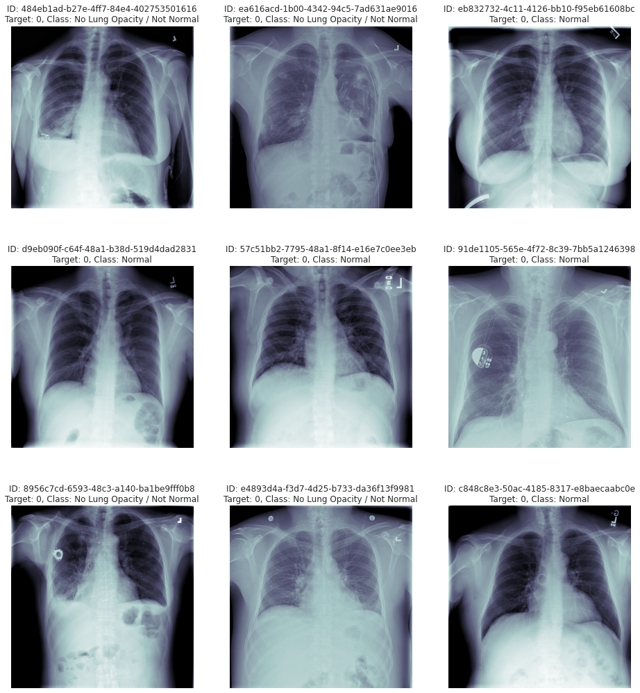

```python
#Images without pneumonia
show_dicom_images(data = training_data.loc[(training_data['Target'] == 0)].sample(9),df = training_data, img_path ="train_images" )
```

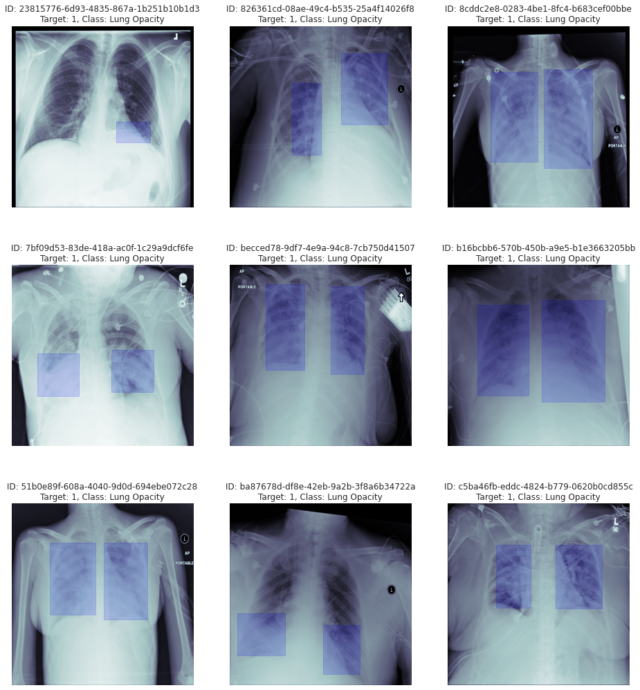

```python
#Images with pneumonia
show_dicom_images(data = training_data.loc[(training_data['Target'] == 1)].sample(9),df = training_data, img_path ="train_images")
```

**EDA on Metadata of DICOM Images**

Medical images are stored in a special format known as DICOM files (*.dcm). They contain a combination of header metadata as well as underlying raw image arrays for pixel data. In Python, one popular library to access and manipulate DICOM files is the pydicom module. To use the pydicom library, first find the DICOM file for a given patientId by simply looking for the matching file in the stage_2_train_images/ folder, and the use the pydicom.read_file() method to load the data:

```python
sample_patientId = train_labels['patientId'][0]
dcm_file = training_image_path+'/{}.dcm'.format(sample_patientId)
dcm_data = dicom.read_file(dcm_file)

print('Metadata of the image consists of \n', dcm_data)
```

```
Metadata of the image consists of
 Dataset.file_meta -------------------------------
(0002, 0000) File Meta Information Group Length  UL: 202
(0002, 0001) File Meta Information Version       OB: b'\x00\x01'
(0002, 0002) Media Storage SOP Class UID         UI: Secondary Capture Image Storage
(0002, 0003) Media Storage SOP Instance UID      UI: 1.2.276.0.7230010.3.1.4.8323329.28530.1517874485.775526
(0002, 0010) Transfer Syntax UID                 UI: JPEG Baseline (Process 1)
(0002, 0012) Implementation Class UID            UI: 1.2.276.0.7230010.3.0.3.6.0
(0002, 0013) Implementation Version Name         SH: 'OFFIS_DCMTK_360'
-------------------------------------------------
(0008, 0005) Specific Character Set              CS: 'ISO_IR 100'
(0008, 0016) SOP Class UID                       UI: Secondary Capture Image Storage
(0008, 0018) SOP Instance UID                    UI: 1.2.276.0.7230010.3.1.4.8323329.28530.1517874485.775526
(0008, 0020) Study Date                          DA: '19010101'
(0008, 0030) Study Time                          TM: '000000.00'
(0008, 0050) Accession Number                    SH: ''
(0008, 0060) Modality                            CS: 'CR'
(0008, 0064) Conversion Type                     CS: 'WSD'
(0008, 0090) Referring Physician's Name          PN: ''
(0008, 103e) Series Description                  LO: 'view: PA'
(0010, 0010) Patient's Name                      PN: '0004cfab-14fd-4e49-80ba-63a80b6bddd6'
(0010, 0020) Patient ID                          LO: '0004cfab-14fd-4e49-80ba-63a80b6bddd6'
(0010, 0030) Patient's Birth Date                DA: ''
(0010, 0040) Patient's Sex                       CS: 'F'
(0010, 1010) Patient's Age                       AS: '51'
(0018, 0015) Body Part Examined                  CS: 'CHEST'
(0018, 5101) View Position                       CS: 'PA'
(0020, 000d) Study Instance UID                  UI: 1.2.276.0.7230010.3.1.2.8323329.28530.1517874485.775525
(0020, 000e) Series Instance UID                 UI: 1.2.276.0.7230010.3.1.3.8323329.28530.1517874485.775524
(0020, 0010) Study ID                            SH: ''
(0020, 0011) Series Number                       IS: '1'
(0020, 0013) Instance Number                     IS: '1'
(0020, 0020) Patient Orientation                 CS: ''
(0028, 0002) Samples per Pixel                   US: 1
(0028, 0004) Photometric Interpretation          CS: 'MONOCHROME2'
(0028, 0010) Rows                                US: 1024
(0028, 0011) Columns                             US: 1024
(0028, 0030) Pixel Spacing                       DS: [0.14300000000000002, 0.14300000000000002]
(0028, 0100) Bits Allocated                      US: 8
(0028, 0101) Bits Stored                         US: 8
(0028, 0102) High Bit                            US: 7
(0028, 0103) Pixel Representation                US: 0
(0028, 2110) Lossy Image Compression             CS: '01'
(0028, 2114) Lossy Image Compression Method      CS: 'ISO_10918_1'
(7fe0, 0010) Pixel Data                          OB: Array of 142006 elements
```

```python
# Adding necessary Columns for EDA from Metadata of the DICOM Images

columns_to_add = ['Modality', 'PatientAge', 'PatientSex', 'BodyPartExamined', 'ViewPosition', 'ConversionType', 'Rows', 'Columns', 'PixelSpacing']
from tqdm import tqdm, tqdm_notebook

def parse_dicom_data(data_df, data_path):
  for col in columns_to_add:
    data_df[col] = None
  image_names = os.listdir('train_images')

  for i, img_name in tqdm_notebook(enumerate(image_names)):
    imagepath = os.path.join('train_images', img_name)
    data_img = dicom.read_file(imagepath)
    idx = (data_df['patientId'] == data_img.PatientID)
    data_df.loc[idx, 'Modality'] = data_img.Modality
    data_df.loc[idx, 'PatientAge'] = pd.to_numeric(data_img.PatientAge)
    data_df.loc[idx, 'PatientSex'] = data_img.PatientSex
    data_df.loc[idx, 'BodyPartExamined'] = data_img.BodyPartExamined
    data_df.loc[idx, 'ViewPosition'] = data_img.ViewPosition
    data_df.loc[idx, 'ConversionType'] = data_img.ConversionType
    data_df.loc[idx, 'Rows'] = data_img.Rows
    data_df.loc[idx, 'Columns'] = data_img.Columns
    data_df.loc[idx, 'PixelSpacing'] = str.format("{:4.3f}", data_img.PixelSpacing[0])
```

```python
# Parse DICOM Images to pull the metadata from them
parse_dicom_data(training_data,'train_images')
```

```python
print('So after parsing the information from the dicom images, our training_data dataframe has {} rows and {} columns and it looks like:\n'.format(training_data.shape[0], training_data.shape[1]))
training_data.head()
```

```
So after parsing the information from the dicom images, our training_data dataframe has 30227 rows and 17 columns and it looks like:
```

|  | patientId | x | y | width | height | Target | class | path | Modality | PatientAge | PatientSex | BodyPartExamined | ViewPosition | ConversionType | Rows | Columns | PixelSpacing |
| --- | --- | --- | --- | --- | --- | --- | --- | --- | --- | --- | --- | --- | --- | --- | --- | --- | --- |
| 0 | 0004cfab-14fd-4e49-80ba-63a80b6bddd6 | NaN | NaN | NaN | NaN | 0 | No Lung Opacity / Not Normal | train_images/0004cfab-14fd-4e49-80ba-63a80b6bd... | CR | 51 | F | CHEST | PA | WSD | 1024 | 1024 | 0.143 |
| 1 | 00313ee0-9eaa-42f4-b0ab-c148ed3241cd | NaN | NaN | NaN | NaN | 0 | No Lung Opacity / Not Normal | train_images/00313ee0-9eaa-42f4-b0ab-c148ed324... | CR | 48 | F | CHEST | PA | WSD | 1024 | 1024 | 0.194 |
| 2 | 00322d4d-1c29-4943-afc9-b6754be640eb | NaN | NaN | NaN | NaN | 0 | No Lung Opacity / Not Normal | train_images/00322d4d-1c29-4943-afc9-b6754be64... | CR | 19 | M | CHEST | AP | WSD | 1024 | 1024 | 0.168 |
| 3 | 003d8fa0-6bf1-40ed-b54c-ac657f8495c5 | NaN | NaN | NaN | NaN | 0 | Normal | train_images/003d8fa0-6bf1-40ed-b54c-ac657f849... | CR | 28 | M | CHEST | PA | WSD | 1024 | 1024 | 0.143 |
| 4 | 00436515-870c-4b36-a041-de91049b9ab4 | 264.0 | 152.0 | 213.0 | 379.0 | 1 | Lung Opacity | train_images/00436515-870c-4b36-a041-de91049b9... | CR | 32 | F | CHEST | AP | WSD | 1024 | 1024 | 0.139 |

```python
#EDA on Modality
print('Modality for the images obtained is: {} \n'.format(training_data['Modality'].unique()[0]))
```

```
Modality for the images obtained is: CR
```

```python
#EDA on Body Part Examined
print('The images obtained are of {} areas.'.format(training_data['BodyPartExamined'].unique()[0]))
```

```
The images obtained are of CHEST areas.
```

```python
#EDA on Understanding Different Positions
(training_data['ViewPosition'].value_counts() / training_data['patientId'].count()) * 100
```

```
AP    50.607073
PA    49.392927
Name: ViewPosition, dtype: float64
```

```python
#AP : Anterior/Posterior (AP)
#PA : Posterior/Anterior (PA)
```

```python
#EDA on Conversion Type
print('Conversion Type for the data in Training Data: ', training_data['ConversionType'].unique()[0])
```

```
Conversion Type for the data in Training Data:  WSD
```

```python
#EDA on Gender
(training_data['PatientSex'].value_counts() / training_data['patientId'].count()) * 100
```

```
M    56.955702
F    43.044298
Name: PatientSex, dtype: float64
```

```python
#Function to plot graphs on different attributes of the dataframe
def drawgraphs(data_file, columns, hue = False, width = 15, showdistribution = True):
  if (hue):
    print('Creating graph for: {} and {}'.format(columns, hue))
  else:
    print('Creating graph for : {}'.format(columns))
  length = len(columns) * 6
  total = float(len(data_file))

  fig, axes = plt.subplots(nrows = len(columns) if len(columns) > 1 else 1, ncols = 1, figsize = (width, length))
  for index, content in enumerate(columns):
    plt.title(content)

    currentaxes = 0
    if (len(columns) > 1):
      currentaxes = axes[index]
    else:
      currentaxes = axes

    if (hue):
      sns.countplot(x = columns[index], data = data_file, ax = currentaxes, hue = hue)
    else:
      sns.countplot(x = columns[index], data = data_file, ax = currentaxes)

    if(showdistribution):
      for p in (currentaxes.patches):
        height = p.get_height()
        if (height > 0 and total > 0):
          currentaxes.text(p.get_x() + p.get_width()/2., height + 3, '{:1.2f}%'.format(100*height/total), ha = "center")
```

```
Creating graph for: ['PatientSex'] and class
```

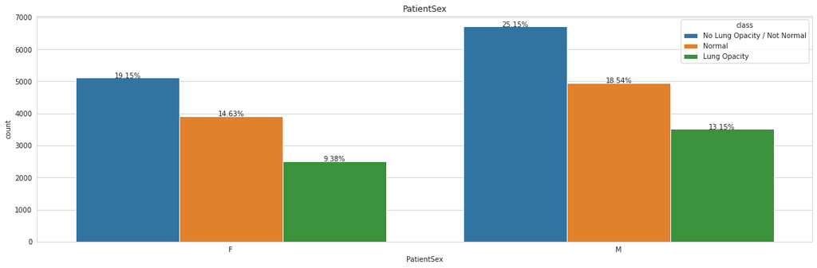

```python
#EDA on PatientSex and Count of patientId - Hue by Class
drawgraphs(data_file = training_data.drop_duplicates('patientId'), columns = ['PatientSex'], hue = 'class', width = 20, showdistribution = True)
```

```
Creating graph for: ['PatientSex'] and Target
```

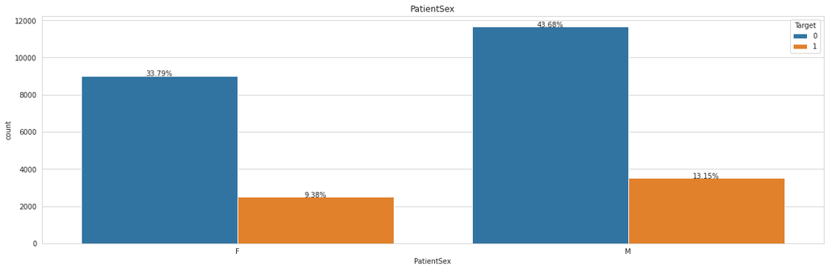

```python
#EDA on PatientSex and Count of patientId. Split by Target
drawgraphs(data_file = training_data.drop_duplicates('patientId'), columns = ['PatientSex'], hue = 'Target', width = 20, showdistribution = True)
```

```python
#EDA on PatientAge
#Split PatientAge based on into PatientAgeBins
custom_array = np.linspace(0, 100, 11)
training_data['PatientAgeBins'] = pd.cut(training_data['PatientAge'], custom_array)
training_data.drop_duplicates('patientId')['PatientAgeBins'].value_counts()
```

```
(50.0, 60.0]     6619
(40.0, 50.0]     5048
(60.0, 70.0]     4279
(30.0, 40.0]     3936
(20.0, 30.0]     3205
(10.0, 20.0]     1468
(70.0, 80.0]     1452
(0.0, 10.0]       435
(80.0, 90.0]      233
(90.0, 100.0]       4
Name: PatientAgeBins, dtype: int64
```

```
Creating graph for : ['PatientAgeBins']
```

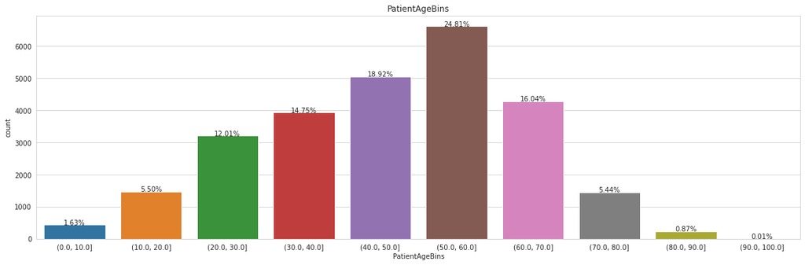

```python
#Distribution on Count of Patients based on PatientAgeBins
drawgraphs(data_file = training_data.drop_duplicates('patientId'), columns = ['PatientAgeBins'], width = 20, showdistribution = True)
```

```python
#As per our dataset the major images belong to age group between 50 and 60
```

```
Creating graph for: ['PatientAgeBins'] and PatientSex
```

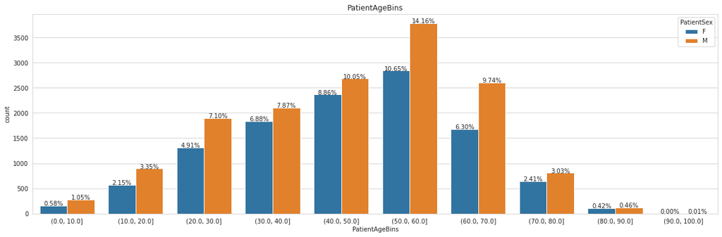

```python
drawgraphs(data_file = training_data.drop_duplicates('patientId'), columns = ['PatientAgeBins'], hue = 'PatientSex', width = 20, showdistribution = True)
```

```python
#The Images for Male are more than of Female
```

```
Creating graph for: ['PatientAgeBins'] and class
```

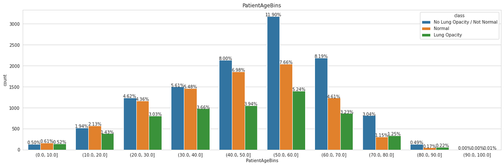

```python
drawgraphs(data_file = training_data.drop_duplicates('patientId'), columns = ['PatientAgeBins'], hue = 'class', width = 20, showdistribution = True)
```

```
Creating graph for: ['PatientAgeBins'] and Target
```

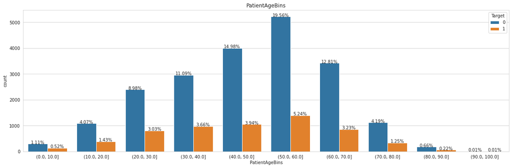

```python
drawgraphs(data_file = training_data.drop_duplicates('patientId'), columns = ['PatientAgeBins'], hue = 'Target', width = 20, showdistribution = True)
```

**Image Classification**

```python
#Converting the train images from DICOM to JPEG
train_path = "train_images"
PNG = False

jpg_folder_path = 'JPG_test' #Output folder
images_path = os.listdir(train_path)
for n, image in enumerate(images_path):
    ds = dicom.dcmread(os.path.join(train_path, image))
    pixel_array_numpy = ds.pixel_array
    if PNG == False:
        image = image.replace('.dcm', '.jpg')
    else:
        image = image.replace('.dcm', '.png')
    cv2.imwrite(os.path.join(jpg_folder_path, image), pixel_array_numpy)
    if n % 100 == 0:
        print('{} images converted'.format(n))
```

[output not shown]

[output cut: 253 more lines]

```python
print("Number of images :", len(os.listdir(jpg_folder_path)))
```

```
Number of images : 26718
```

```python
os.listdir(jpg_folder_path)
```

[output not shown]

[output cut: 946 more lines]

[output not shown]